# Using Sorghum as an outgroup to find syntenic regions in Maize: regenerating subgenome assignments in maize

This analysis is based on the file: **../Data/sorghum_v1_vs_maize_v1.tab**

We begin with SynMap output based on the [Schnable 2011](https://www.ncbi.nlm.nih.gov/pmc/articles/PMC3053962/) paper (see [my notes](https://www.evernote.com/shard/s303/nl/52987123/1ce74f11-98a0-4854-b363-3172e79eeae3) for details on parameter and download options).

# Import SynMap and GO Term Data

We parse the SynMap output file with ks/kn values (i.e. a DAGChainer file) to a flat format using a perl script (parseKsKnFile.pl) and import the data into R. Some ks and kn values are empty, which is to be expected. These are ignored for the purposes of finding the median, but included in the results if they are in a block that meets the cutoff criteria. GO terms related to Maize gene models are imported as well.

# Choosing a KS cutoff value

We need to select a cutoff value for ks (synonymous mutation rate) to differentiate between the most recent alpha duplication event and the previous beta duplication. Looking at ks value frequency (left), we should not see any obvious cutoff point. By transforming ks values to block median values, we should see two (or more) peaks (center). In this (center) graph, the first peak represents orthologs and the second represents homeologs from “pregrass tetraploidy”. If the vertical line separates the first two peaks sufficently, it is probably a good enough value. If not, we need to pick a new cutoff value for ks. Viewing the log10 transform of the ks values helps differentiate types of homologs (better version of this graph with color can be generated in CoGe).

You have selected the log10(ks) cutoff value to be **0**. Again, this should ideally separate two peaks in the middle graph.

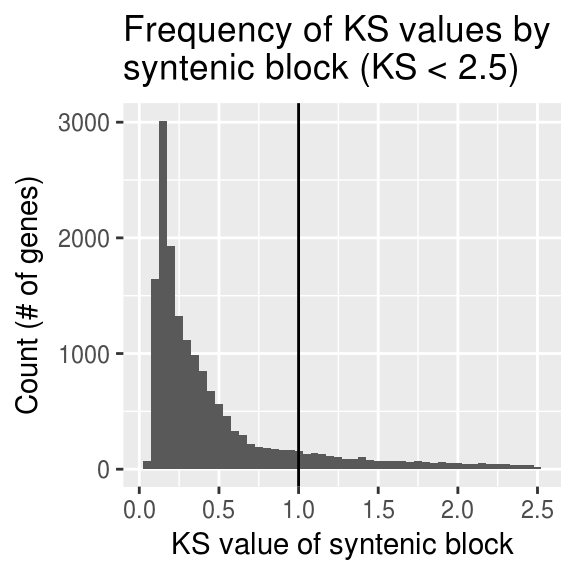

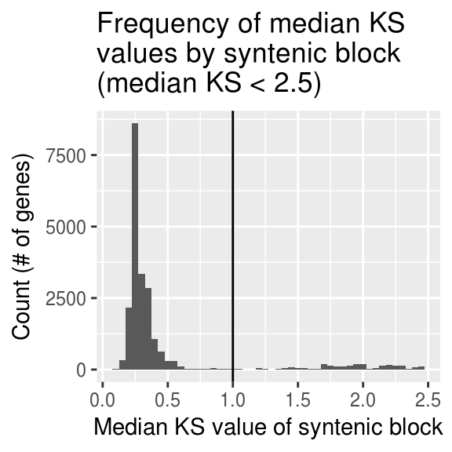

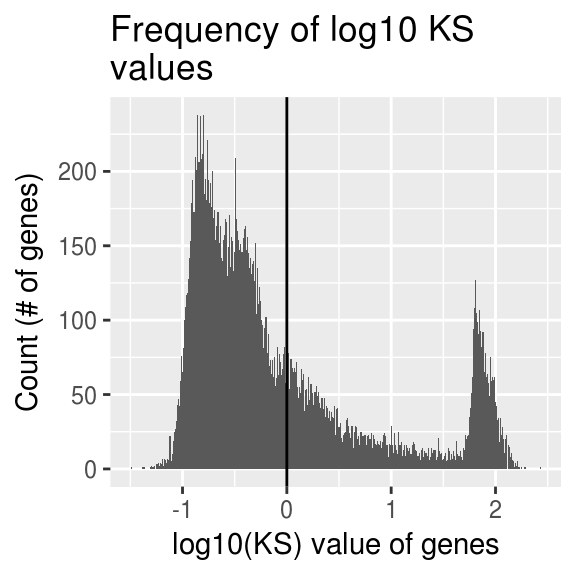

# Major Syntenic Blocks

Regions of synteny are not confined to a 1:1 relationship between Sorghum and Maize chromosomes. Where multiple regions in Maize are syntenic to the same region on Sorghum, we can assume this is a result of the whole genome duplication even. These are the regions which will be sorted into subgenome 1 and subgenome 2.

Table

| Chromosome | b8082_1 | b8082_2 | b8082_3 | b8082_4 | b8082_5 | b8082_6 | b8082_7 | b8082_8 | b8082_9 | b8082_10 | total |
| --- | --- | --- | --- | --- | --- | --- | --- | --- | --- | --- | --- |
| a6807_1 | 2359 | na | na | na | 646 | na | na | na | 688 | na | 3693 |
| a6807_2 | na | 866 | na | na | na | na | 1504 | na | na | na | 2370 |
| a6807_3 | na | na | 1784 | na | na | na | na | 1118 | na | na | 2902 |
| a6807_4 | na | na | na | 935 | 1369 | na | na | na | na | na | 2304 |
| a6807_5 | na | 181 | 16 | 403 | na | na | na | na | na | 21 | 621 |
| a6807_6 | na | 997 | na | na | na | na | na | na | na | 666 | 1663 |
| a6807_7 | 456 | na | na | 435 | na | 103 | na | na | na | 165 | 1159 |
| a6807_8 | 183 | 13 | 260 | 14 | na | 16 | na | na | na | 213 | 699 |
| a6807_9 | na | na | na | na | na | 818 | na | 455 | na | 51 | 1324 |
| a6807_10 | na | na | na | na | 205 | 509 | na | na | 689 | na | 1403 |

There are **0** unaligned sorghum chromosome(s) in the above table. If there are any unaligned sorghum chromosomes, consider picking a new ks cutoff.

# SubGenomes

In order to separate subgenome 1 from subgenome 2, we implement a greedy algorithm to collect non-overlapping (when projected on sorghum) syntenic blocks by size. **(TODO)**

foreach sorghum chromosome, set the largest syntenic chromosome (by gene) as sub1. Foreach additional syntenic chromosome if doesn’t overlap what is already in sub1, add it to sub1. Else, if it does not overlap anything in sub2, add to sub2. Else toss. After all syntenic chromosomes are process for this sorghum chromosome, count the number of genes in sub1 and sub2. If sub2 is bigger, switch them. *Toss out “small” syntenic chromosomes (51 genes or less?), and consider a tolerance for how much overlap must occur to consider it a true overlap. Also consider switching to gene level overlap rather than whole-chromosome start/stop values.

## Compared to Paper

How many chromosomes with synteny to sorghum were correctly placed in subgenome 1 or subgenome 2? Items in “Paper” only are missed subgenome assignments. Items in “Greedy” only are false assignments. Items in center are correct. (this is an unfair comparison if I sorted by hand)

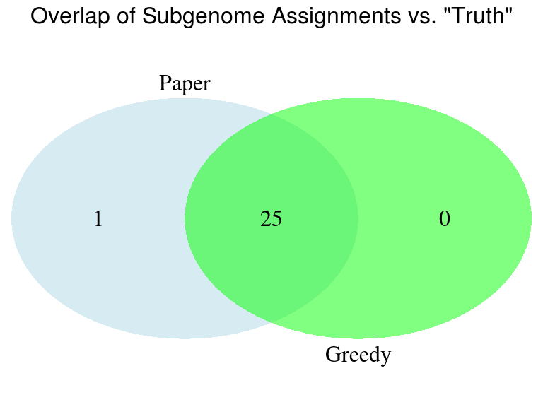

# GOTerms

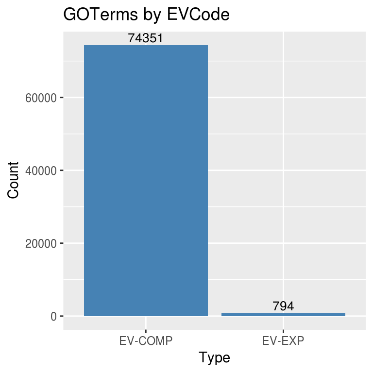

GO Terms by subgenome. If the GO Term is assigned to any gene in the subgenome, it is counted once for that subgenome. This is a presence/absence test.

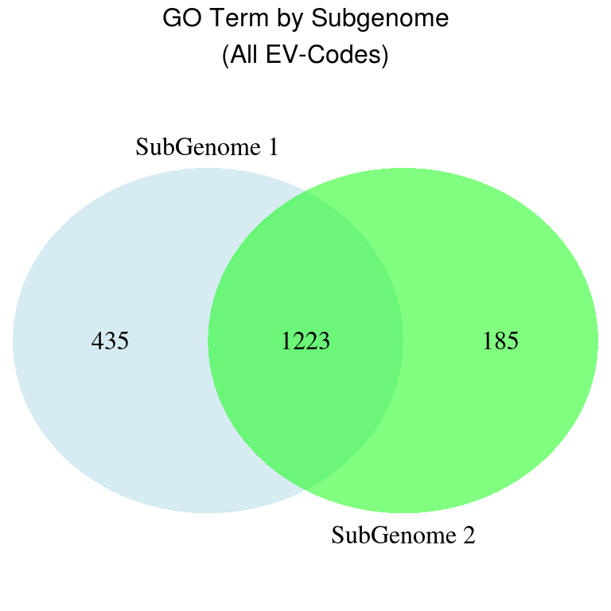

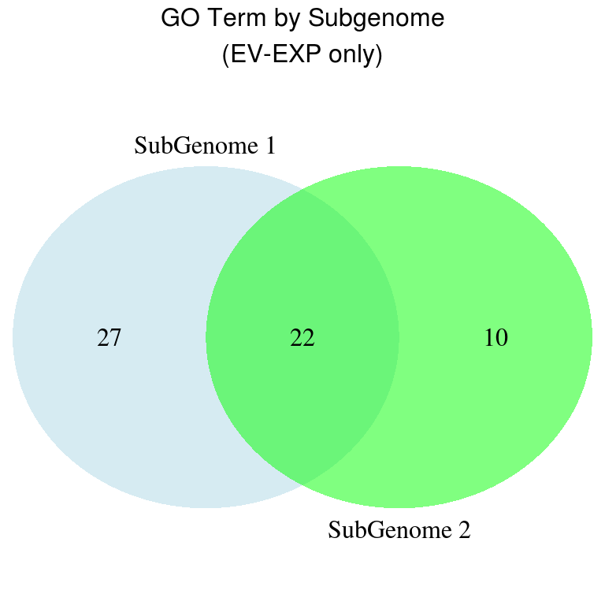

GOTerm assignments to genes by subgenome, which takes into account the gene-GOTerm pairings and considers homeologs equivalent for the purposes of determining overlap in assignments.

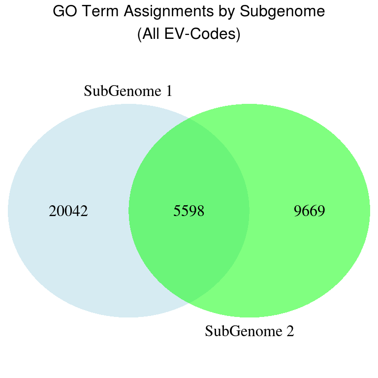

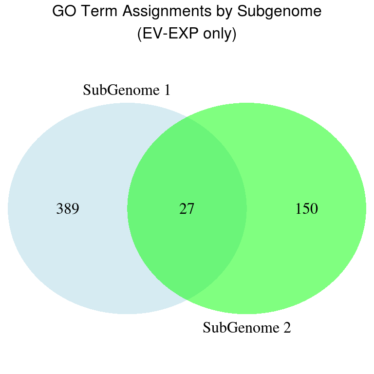

# Wrapup

The results of this report are available at **../Output/recoveredSubGenomes_sorghum_v1_vs_maize_v1.tab**.